# Task_3_Descriptive_Stats.rmd

Sean Franco

2025-07-25

**Name:** Task_3_Descriptive_Stats.rmd  
**Purpose:** To clean, and explore Ohio’s registered apprentice data.  
**Author:** Sean Franco  
**Date Created:** 2025_07_23  
**Inputs:** 4 Files: ‘Apprenticeship Data Dictionary.xlsx’; oh_appr_person.csv; oh_appr_program.csv; 2-6 digit_2022_Codes.xlsx  
**Outputs:** Task_3_Descriptive_Stats.html  
**Notes:** 3/3 Interview file submission.

The code chunk below loads the 2 apprentice project datasets, and loads necessary libraries for R Markdown.

```r
#install.packages('devtools')
#devtools::install_github("physicsland/ezids")
#library(devtools)

library(ezids)

data_wd <- "C:/Users/18045/Documents/R/OSU_Project/Data"
file_wd <- "C:/Users/18045/Documents/R/OSU_Project"

setwd(file_wd)
#install.packages('pacman')
library('pacman')
pacman::p_load(ggplot2, xtable, dplyr,  readxl, gridExtra, xtable,
               readr, car, xtable, knitr, kableExtra, forcats)

#LoadData----
#appr_dict <- read_excel(file.path(data_wd, 'Apprenticeship Data Dictionary.xlsx'))
appr_person_df <- read.csv(file.path(data_wd, 'oh_appr_person.csv'))
appr_prog_df <- read.csv(file.path(data_wd, 'oh_appr_program.csv'))
naics_df <- read_excel(file.path(data_wd, "2-6 digit_2022_Codes.xlsx")) #download NAICS codes here: https://www.census.gov/naics/?48967 selecting the 2-6 digit 2022 Code File [XLSX, 81KB]
naics_df <- naics_df[-1, -c(1, 4,5)] #remove first row, and 1, 4, 5 columns
names(naics_df) <- trimws(names(naics_df))
```

This code chunk applies demographic levels for factor variables such as Race, Gender, Ethnicity, Veteran Status, Disabled Status, and Education level.

```r
#applying dictionary terms to demographic information

appr_person_df <- appr_person_df %>%
      mutate(across(c(Race, Gender, Ethnicity), ~ na_if(., "")))%>%
      mutate(
        education = case_when(education == 1 ~ '8th grade or less',
                                    education == 1 ~ '8th grade or less',
                                    education == 2 ~ '9th to 12th grade',
                                    education == 3 ~ 'GED',
                                    education == 4 ~ 'High school or greater',
                                    education == 5 ~ 'Unknown',
                                    education == 6 ~ 'Post-secondary or technical training' ),

            Ethnicity = case_when(Ethnicity == 'H' ~ 'Hispanic',
                                  Ethnicity == 'N' ~ 'Not Hispanic',
                                  Ethnicity == 'NP' ~ 'Not Provided'),

            apprStatus = case_when(apprStatus == 'CA' ~ 'Cancelled',
                                  apprStatus == 'CO' ~ 'Completed',
                                  apprStatus == 'RE' ~ 'Registered',
                                  apprStatus == 'RI' ~ 'Suspended/Reinstated/Transferred',
                                  apprStatus == 'SU' ~ 'Suspended/Reinstated/Transferred',
                                  apprStatus == 'TR' ~ 'Suspended/Reinstated/Transferred'),

            Gender = case_when(Gender == "M"~ 'Male',
                               Gender == 'F' ~ 'Female'),

            Disabled = case_when(Disabled  == "Y"~ 'Yes',
                               Disabled  == 'N' ~ 'No',
                               Disabled == 'NP' ~ "Not Provided"),

            VetStatInd = case_when(VetStatInd  == "Y"~ 'Yes',
                               VetStatInd  == 'N' ~ 'No',
                               VetStatInd == 'NP' ~ "Not Provided")
                               )
```

This code chunk caps the Age at Start of apprenticeship to an age range inclusive from age 14 to age 90. This was performed to accurately record respondents who may enter the workforce as a teenager. The lower start age floor of 14 was included to identify participants who sought the apprenticeship program before legal working age or representative of other arrangements such as but not limited to emancipation. The upper start age cap of 90 was included to account for participants who sought the apprenticeship program later in life. start ages reported outside of this range were flagged and not included in this study because they were low in count, and have an increased chance they were erroneous.

```r
#Binning start Ages and flagging erronous ages
appr_person_df$age_flag <- appr_person_df$AgeAtStart >= 14 & appr_person_df$AgeAtStart <= 90

appr_person_df$start_age_clean <- ifelse(appr_person_df$age_flag, appr_person_df$AgeAtStart, NA)

appr_person_df$age_bin <- cut(appr_person_df$start_age_clean,
                              breaks = c(14, 20, 30, 40, 50, 60, 70, 90),
                              right = FALSE,
                              labels = c("14–19", "20–29", "30–39", "40–49", "50–59", "60–69", "70-90"))

appr_person_df$age_bin <- factor(appr_person_df$age_bin, levels = c("14–19", "20–29", "30–39", "40–49", "50–59", "60–69", "70-90"),
  ordered = TRUE)
```

Start and exit wages in the apprentice program were cleaned and binned into a range from below $7.25/hour to over $40/hour. The lower wage bound represents tip workers and other low-wage earners below the federal minimum wage of $7.25/hour. The upper wage bound represents the fewer high-wage earners and caps outliers. Wage bins were consistent for start and exit wages for consistency. Wage bin are incremented by ~$5 intervals from below $7.25 up to $20/hour, then by ~$10 intervals from $20/hour to a cap of $40+/hour. Besides protecting individual wages (which may invovle a privacy concern) the wage bins highlight economic utility differences. For example, the difference in utility between earning $15/hour and $30/hour is meaningful even when accounting for other variables like the number of dependents.

```r
#Binning start wages

appr_person_df$st_wage_flag <- appr_person_df$startingWage >= 7.25 & appr_person_df$startingWage <= 40

appr_person_df$st_wage_clean <- ifelse(appr_person_df$st_wage_flag, appr_person_df$startingWage, NA)

appr_person_df$st_wage_bin <- cut(appr_person_df$startingWage,
                              breaks = c(-Inf, 7.25, 15, 20, 30, 40, Inf),
                              right = FALSE,
                              labels = c("Below $7.25", "$7.25–$14", "$15–$19", "$20–$29", "$30–$39", "$40+"))

appr_person_df$st_wage_bin <- factor(appr_person_df$st_wage_bin, levels = c("Below $7.25", "$7.25–$14", "$15–$19", "$20–$29", "$30–$39", "$40+"),
  ordered = TRUE)

#Binning exit wages

appr_person_df$end_wage_flag <- appr_person_df$exitWage >= 7.25 & appr_person_df$exitWage <= 40

appr_person_df$end_wage_clean <- ifelse(appr_person_df$end_wage_flag, appr_person_df$exitWage, NA)

appr_person_df$end_wage_bin <- cut(appr_person_df$exitWage,
                               breaks = c(-Inf, 7.25, 15, 20, 30, 40, Inf),
                               right = FALSE,
                               labels = c("Below $7.25", "$7.25–$14", "$15–$19", "$20–$29", "$30–$39", "$40+"))

appr_person_df$end_wage_bin <- factor(appr_person_df$end_wage_bin, levels = c("Below $7.25", "$7.25–$14", "$15–$19", "$20–$29", "$30–$39", "$40+"),
  ordered = TRUE)
```

Presented below are tables and plots of the demographic information of the apprentice participants which includes Ethnicity, Veteran Status, Gender, Race, Disabled Status, Education level, and Program Age Start Bins.

**Ethnicity**

66% of apprentice participants reported Not Hispanic ethnicity, 31% did not provide a response, and 3% reported Hispanic ethnicity. This suggests that the apprentice program may need additional marketing towards Hispanics to enter the program. Additionally self-reporting ethnicity may be tied to caution which could explain the larger share of the “Not Provided” response.

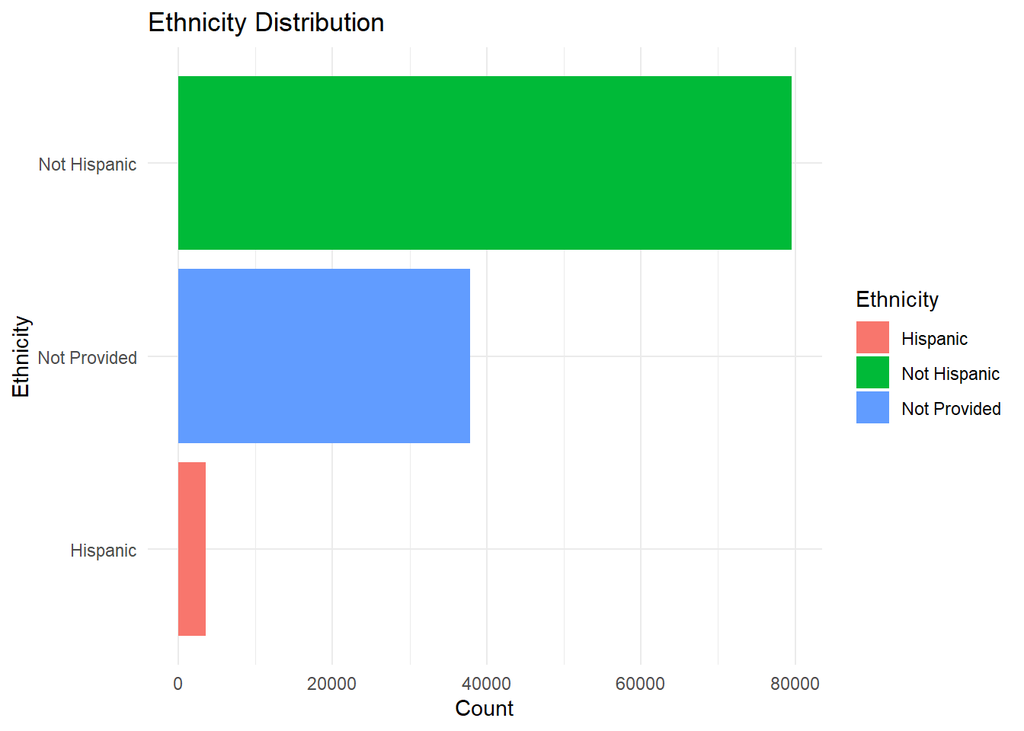

```r
appr_person_df %>%
  count(Ethnicity) %>%
  arrange(desc(n)) %>%
  mutate(
    Count = scales::comma(n),
    Percent = scales::percent(n / sum(n))
  ) %>%
  ggplot( aes(x = reorder(Ethnicity, n), y = n, fill = Ethnicity)) +
  geom_bar(stat = "identity") +
  coord_flip() +
  labs(
    title = "Ethnicity Distribution",
    x = "Ethnicity",
    y = "Count"
  ) +
  theme_minimal()
```

```r
appr_person_df %>%
  count(Ethnicity) %>%
  arrange(desc(n)) %>%
  mutate(
    Count = scales::comma(n),
    Percent = scales::percent(n / sum(n))
  ) %>%
  select(Ethnicity, Count, Percent) %>%
  kable(
    col.names = c("Ethnicity", "Count", "Percent"),
    caption = "Ethnicity Distribution"
  ) %>%
  kable_styling(bootstrap_options = c("striped", "hover", "condensed"))
```

Ethnicity Distribution

| Ethnicity | Count | Percent |
| --- | --- | --- |
| Not Hispanic | 79,485 | 66% |
| Not Provided | 37,849 | 31% |
| Hispanic | 3,568 | 3% |

**Veteran Status**

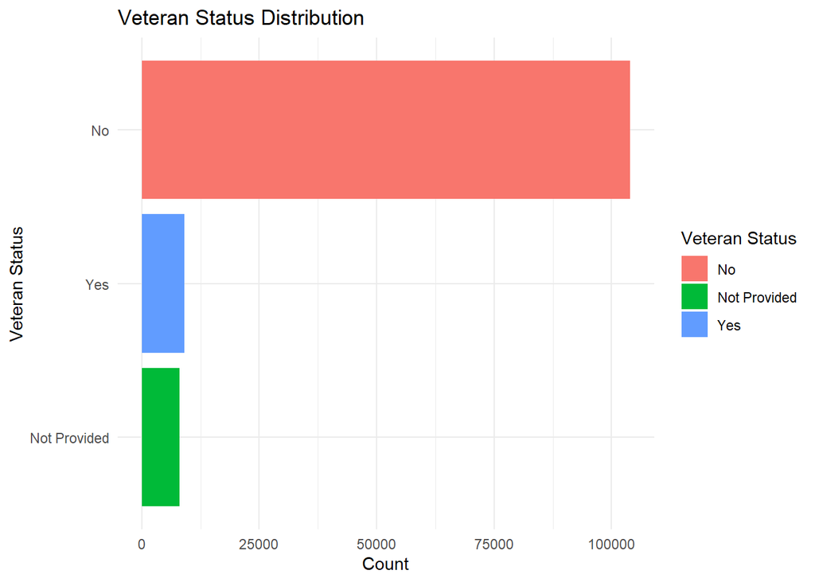

```r
appr_person_df %>%
  count(VetStatInd) %>%
  arrange(desc(n)) %>%
  mutate(
    Count = scales::comma(n),
    Percent = scales::percent(n / sum(n))
  ) %>%
  ggplot( aes(x = reorder(VetStatInd, n), y = n, fill = VetStatInd)) +
  geom_bar(stat = "identity") +
  coord_flip() +
  labs(
    title = "Veteran Status Distribution",
    x = "Veteran Status",
    y = "Count"
  ) +
  theme_minimal()+
  scale_fill_discrete(name = "Veteran Status")
```

```r
appr_person_df %>%
  count(VetStatInd) %>%
  arrange(desc(n)) %>%
  mutate(Count = scales::comma(n),
    Percent = scales::percent(n / sum(n))) %>% select(VetStatInd, Count, Percent) %>%
  kable(col.names = c("Veteran Status", "Count", "Percent"), caption = "Veteran Status Distribution") %>%
  kable_styling(bootstrap_options = c("striped", "hover", "condensed"))
```

Veteran Status Distribution

| Veteran Status | Count | Percent |
| --- | --- | --- |
| No | 103,881 | 85.92% |
| Yes | 9,007 | 7.45% |
| Not Provided | 8,014 | 6.63% |

**Gender**

93% of participants indicated a male gender, and 7% of participants indicated a female gender. The apprentice program seems to have a higher participation of males than females, which may be reinforced by the type of roles offered, and lack of support systems for female and other marginalized genders.

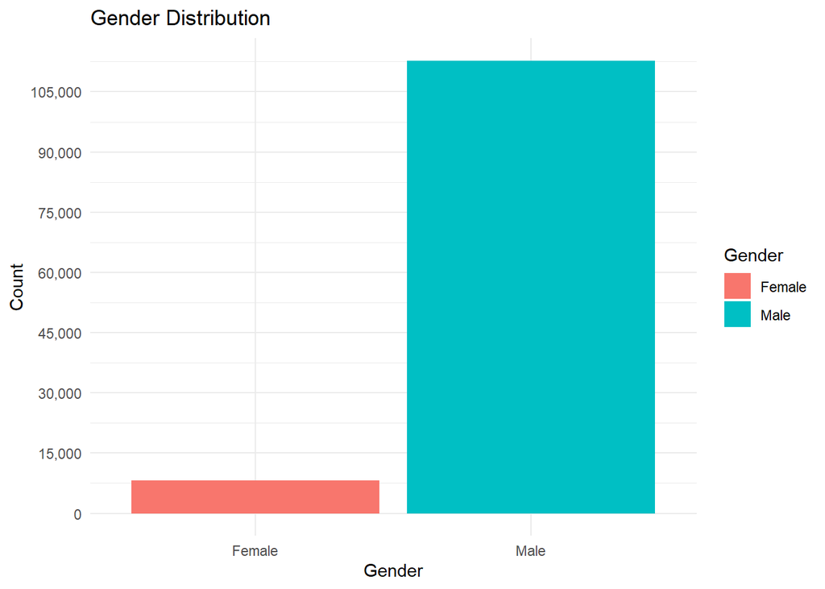

```r
appr_person_df %>%
  count(Gender) %>%
  arrange(desc(n)) %>%
  mutate(
    Count = scales::comma(n),
    Percent = scales::percent(n / sum(n))
  ) %>%
  ggplot( aes(x = reorder(Gender, n), y = n, fill = Gender)) +
  geom_bar(stat = "identity") +

  labs(
    title = "Gender Distribution",
    x = "Gender",
    y = "Count"
  ) +
  scale_y_continuous(breaks = seq(0, 200000, by = 15000),
  labels = scales::comma) +
  theme_minimal()
```

```r
appr_person_df %>%
  count(Gender) %>%
  arrange(desc(n)) %>%
  mutate(Count = scales::comma(n),
    Percent = scales::percent(n / sum(n))) %>% select(Gender, Count, Percent) %>%
  kable(col.names = c("Gender Status", "Count", "Percent"), caption = "Gender Status Distribution") %>%
  kable_styling(bootstrap_options = c("striped", "hover", "condensed"))
```

Gender Status Distribution

| Gender Status | Count | Percent |
| --- | --- | --- |
| Male | 112,769 | 93% |
| Female | 8,133 | 7% |

**Race**

Around 79% of participants identified as white, 14% of participants identified as black or African-American, and ~6% total were a mix of blank or “do not wish to answer” responses.

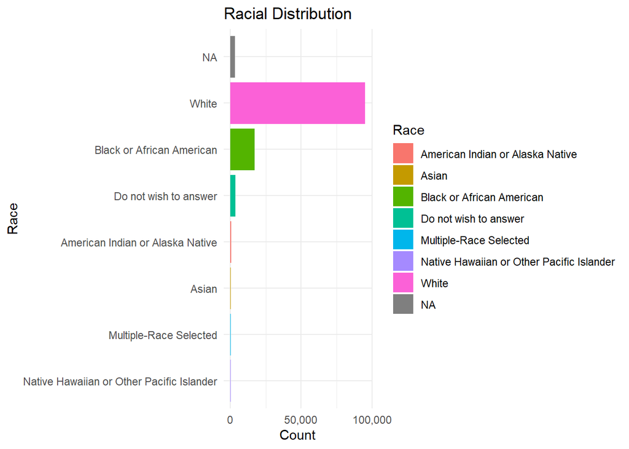

```r
appr_person_df %>%
  count(Race) %>%
  arrange(desc(n)) %>%
  mutate(
    Count = scales::comma(n),
    Percent = scales::percent(n / sum(n))
  ) %>%
  ggplot( aes(x = reorder(Race, n), y = n, fill = Race)) +
  geom_bar(stat = "identity") +
  coord_flip() +
  labs(
    title = "Racial Distribution",
    x = "Race",
    y = "Count"
  ) +
  scale_y_continuous(breaks = seq(0, 150000, by = 50000),
  labels = scales::comma) +
  theme_minimal()
```

```r
appr_person_df %>%
  count(Race) %>%
  arrange(desc(n)) %>%
  mutate(Count = scales::comma(n),
    Percent = scales::percent(n / sum(n))) %>% select(Race, Count, Percent) %>%
  kable(col.names = c("Race Status", "Count", "Percent"), caption = "Race Status Distribution") %>%
  kable_styling(bootstrap_options = c("striped", "hover", "condensed"))
```

Race Status Distribution

| Race Status | Count | Percent |
| --- | --- | --- |
| White | 95,300 | 78.824% |
| Black or African American | 17,196 | 14.223% |
| Do not wish to answer | 3,513 | 2.906% |
| NA | 3,430 | 2.837% |
| American Indian or Alaska Native | 603 | 0.499% |
| Asian | 447 | 0.370% |
| Multiple-Race Selected | 224 | 0.185% |
| Native Hawaiian or Other Pacific Islander | 189 | 0.156% |

**Disabled Status**

85% of respondents selected “Not Provided” for their disabled status. Less than 0% indicated they identified as disabled. This suggests that respondents view this metric on a very personal level to opt out of responding rather than indicate an affirmative or a negative response. This indicates that the participants may wish to keep this type of information private, or that there is a non-professional diagnosis that is wished to be expressed.

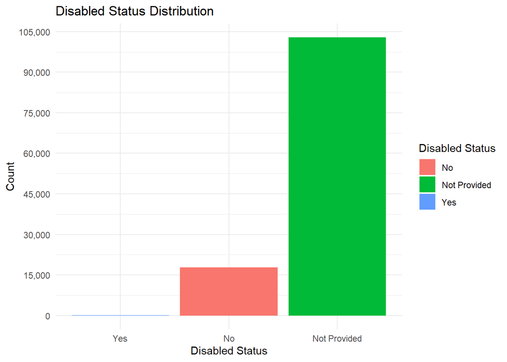

```r
appr_person_df %>%
  count(Disabled) %>%
  arrange(desc(n)) %>%
  mutate(
    Count = scales::comma(n),
    Percent = scales::percent(n / sum(n))
  ) %>%
  ggplot( aes(x = reorder(Disabled, n), y = n, fill = Disabled)) +
  geom_bar(stat = "identity") +

  labs(
    title = "Disabled Status Distribution",
    x = "Disabled Status",
    y = "Count"
  ) +
  scale_y_continuous(breaks = seq(0, 200000, by = 15000),
  labels = scales::comma) +
  theme_minimal() +
  scale_fill_discrete(name = "Disabled Status")
```

```r
appr_person_df %>%
  count(Disabled) %>%
  arrange(desc(n)) %>%
  mutate(Count = scales::comma(n),
    Percent = scales::percent(n / sum(n))) %>% select(Disabled, Count, Percent) %>%
  kable(col.names = c("Disabled Status", "Count", "Percent"), caption = "Disabled Status Distribution") %>%
  kable_styling(bootstrap_options = c("striped", "hover", "condensed"))
```

Disabled Status Distribution

| Disabled Status | Count | Percent |
| --- | --- | --- |
| Not Provided | 102,948 | 85% |
| No | 17,831 | 15% |
| Yes | 123 | 0% |

**Education**

85% of participants indicated that they completed High School or greater. Less than 3% indicated they obtained Post-secondary or technical training. This suggests that the majority of participants 1). completed High School, 2). completed High School and enrolled, but did not obtain a post-secondary or technical training degree or certification.

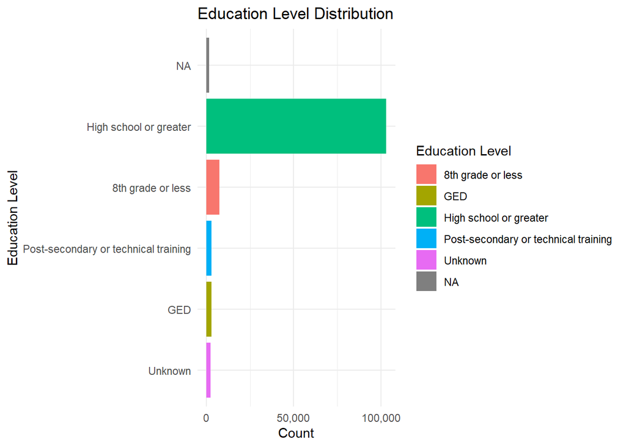

```r
appr_person_df %>%
  count(education) %>%
  arrange(desc(n)) %>%
  mutate(
    Count = scales::comma(n),
    Percent = scales::percent(n / sum(n))
  ) %>%
  ggplot( aes(x = reorder(education, n), y = n, fill = education)) +
  geom_bar(stat = "identity") +
  coord_flip() +
  labs(
    title = "Education Level Distribution",
    x = "Education Level",
    y = "Count"
  ) +
  scale_y_continuous(breaks = seq(0, 150000, by = 50000),
  labels = scales::comma) +
  theme_minimal() +
  scale_fill_discrete(name = "Education Level")
```

```r
appr_person_df %>%
  count(education) %>%
  arrange(desc(n)) %>%
  mutate(Count = scales::comma(n),
    Percent = scales::percent(n / sum(n))) %>% select(education, Count, Percent) %>%
  kable(col.names = c("Education Status", "Count", "Percent"), caption = "Education Status Distribution") %>%
  kable_styling(bootstrap_options = c("striped", "hover", "condensed"))
```

Education Status Distribution

| Education Status | Count | Percent |
| --- | --- | --- |
| High school or greater | 103,152 | 85.32% |
| 8th grade or less | 7,608 | 6.29% |
| Post-secondary or technical training | 3,017 | 2.50% |
| GED | 2,857 | 2.36% |
| Unknown | 2,511 | 2.08% |
| NA | 1,757 | 1.45% |

**Appentrice Age Start Bins**

49% of participants identified between the ages of 20-29, and 25% of participants identified between the ages of 30-39. These age bins compose the majority of ages in the program. Ages were floored at age 14, and capped at age 90 to account for outliers

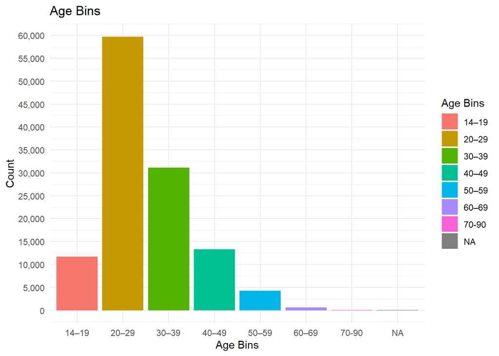

```r
appr_person_df %>%
  count(age_bin) %>%
  mutate(
    Count = scales::comma(n),
    Percent = scales::percent(n / sum(n))
  ) %>%
  ggplot( aes(x = age_bin, y = n, fill = age_bin)) +
  geom_bar(stat = "identity") +
  labs(
    title = "Age Bins",
    x = "Age Bins",
    y = "Count"
  ) +
  scale_y_continuous(breaks = seq(0, 150000, by = 5000),
  labels = scales::comma) +
  theme_minimal() +
  scale_fill_discrete(name = "Age Bins")
```

```r
appr_person_df %>%
  count(age_bin) %>%
  mutate(
    Count = scales::comma(n),
    Percent = scales::percent(n / sum(n))
  ) %>%
  select(age_bin, Count, Percent) %>%
  kable(
    col.names = c("Age Bins At Start of Program", "Count", "Percent"),
    caption = "Age Bins At Start of Program  Distribution"
  ) %>%
  kable_styling(bootstrap_options = c("striped", "hover", "condensed"))
```

Age Bins At Start of Program Distribution

| Age Bins At Start of Program | Count | Percent |
| --- | --- | --- |
| 14–19 | 11,738 | 9.709% |
| 20–29 | 59,726 | 49.400% |
| 30–39 | 31,126 | 25.745% |
| 40–49 | 13,350 | 11.042% |
| 50–59 | 4,249 | 3.514% |
| 60–69 | 646 | 0.534% |
| 70-90 | 52 | 0.043% |
| NA | 15 | 0.012% |

**Apprentice Status**

Overall, the apprentice program has a ~50% attrition rate for participants. This may be due to participants needing additional education to help them succeed in the program or due to other major life changes. Within the context of those societal challenges, a high attrition rate is expected. The success rate of the program is ~33% which is impactful for close to ~41,000 Ohioans. Additionally approximately half that number are currently registered in the program. The status for Suspended/Reinstated/Transferred individuals is lower than 1% of participants. This means that participants typically are committed to their program, and suspension violations are low. The low Suspended/Reinstated/Transferred rate suggests that many individuals either do not report violations or that they are committed to attempting the program.

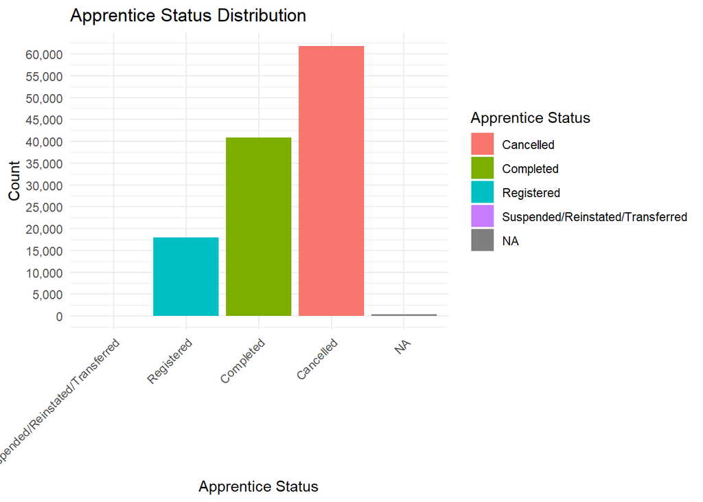

```r
appr_person_df %>%
  count(apprStatus) %>%
  arrange(desc(n)) %>%
  mutate(
    Count = scales::comma(n),
    Percent = scales::percent(n / sum(n))
  ) %>%
  ggplot( aes(x = reorder(apprStatus, n), y = n, fill = apprStatus)) +
  geom_bar(stat = "identity") +

  labs(
    title = "Apprentice Status Distribution",
    x = "Apprentice Status",
    y = "Count"
  ) +
  scale_y_continuous(breaks = seq(0, 150000, by = 5000),
  labels = scales::comma) +
  theme_minimal() +
  scale_fill_discrete(name = "Apprentice Status")+
  theme(axis.text.x = element_text(angle = 45, hjust = 1))
```

```r
appr_person_df %>%
count(apprStatus) %>%
mutate(
Count = scales::comma(n),
Percent = scales::percent(n / sum(n))
) %>%
select(apprStatus, Count, Percent) %>%
kable(
col.names = c("Program Status", "Count", "Percent"),
caption = "Program Status of Program  Distribution"
) %>%
kable_styling(bootstrap_options = c("striped", "hover", "condensed"))
```

Program Status of Program Distribution

| Program Status | Count | Percent |
| --- | --- | --- |
| Cancelled | 61,865 | 51.17% |
| Completed | 40,800 | 33.75% |
| Registered | 17,912 | 14.82% |
| Suspended/Reinstated/Transferred | 18 | 0.01% |
| NA | 307 | 0.25% |

**Start and Exit Wages**

```r
chi_wage <- appr_person_df[
  appr_person_df$st_wage_bin %in% c("Below $7.25", "$7.25–$14", "$15–$19", "$20–$29") &
  appr_person_df$end_wage_bin %in% c("Below $7.25", "$7.25–$14", "$15–$19", "$20–$29"),
]

wage_table <- table(chi_wage$st_wage_bin, chi_wage$end_wage_bin)

wage_table_clean <- wage_table[rowSums(wage_table) > 0, colSums(wage_table) > 0]

chi_wage_results <- chisq.test(wage_table_clean)
```

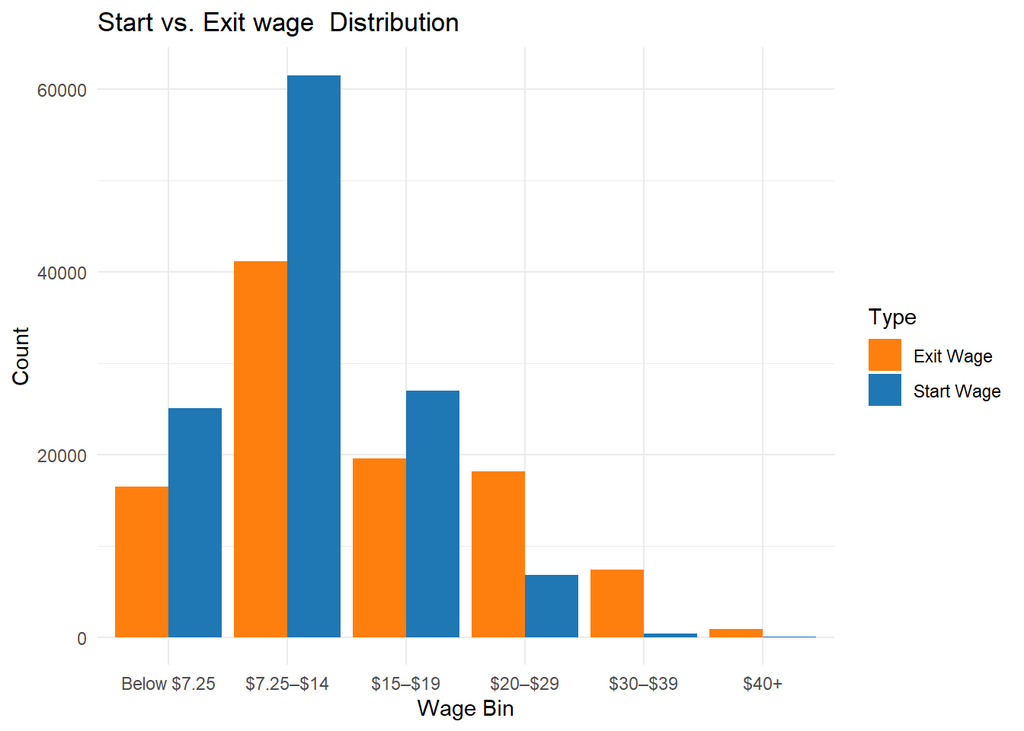

```r
start_tab <- table(appr_person_df$st_wage_bin)
end_tab <- table(appr_person_df$end_wage_bin)

start_df <- as.data.frame(start_tab)
colnames(start_df) <- c("Wage_Bin", "Count")
start_df$Type <- "Start Wage"

end_df <- as.data.frame(end_tab)
colnames(end_df) <- c("Wage_Bin", "Count")
end_df$Type <- "Exit Wage "

wage_plot_df <- rbind(start_df, end_df)

ggplot(wage_plot_df, aes(x = Wage_Bin, y = Count, fill = Type)) +
  geom_bar(stat = "identity", position = "dodge") +
  labs(
    title = "Start vs. Exit wage  Distribution",
    x = "Wage Bin",
    y = "Count"
  ) +
  scale_fill_manual(values = c("Start Wage" = "#1f77b4", "Exit Wage " = "#ff7f0e")) +
  theme_minimal() +
  theme(axis.text.x = element_text(angle = 0, hjust = 0.5))
```

```r
paired_df <- appr_person_df %>%
  filter(!is.na(st_wage_clean), !is.na(end_wage_clean)) %>%
  select(psId, st_wage_clean, end_wage_clean)

wilcox_results <- wilcox.test(paired_df$end_wage_clean, paired_df$st_wage_clean, paired = TRUE)
median_result <- median(paired_df$end_wage_clean - paired_df$st_wage_clean)
```

```r
appr_person_df %>%
  count(st_wage_bin) %>%
  mutate(
    Count = scales::comma(n),
    Percent = scales::percent(n / sum(n))
  ) %>%
  select(st_wage_bin, Count, Percent) %>%
  kable(
    col.names = c("Start Wage", "Count", "Percent"),
    caption = "Start Wage Distribution"
  ) %>%
  kable_styling(bootstrap_options = c("striped", "hover", "condensed"))
```

Start Wage Distribution

| Start Wage | Count | Percent |
| --- | --- | --- |
| Below $7.25 | 25,099 | 20.760% |
| $7.25–$14 | 61,557 | 50.915% |
| $15–$19 | 27,015 | 22.345% |
| $20–$29 | 6,816 | 5.638% |
| $30–$39 | 352 | 0.291% |
| $40+ | 44 | 0.036% |
| NA | 19 | 0.016% |

```r
appr_person_df %>%
  count(end_wage_bin) %>%
  mutate(
    Count = scales::comma(n),
    Percent = scales::percent(n / sum(n))
  ) %>%
  select(end_wage_bin, Count, Percent) %>%
  kable(
    col.names = c("Exit Wage", "Count", "Percent"),
    caption = "Exit Wage Distribution"
  ) %>%
  kable_styling(bootstrap_options = c("striped", "hover", "condensed"))
```

Exit Wage Distribution

| Exit Wage | Count | Percent |
| --- | --- | --- |
| Below $7.25 | 16,514 | 13.66% |
| $7.25–$14 | 41,170 | 34.05% |
| $15–$19 | 19,593 | 16.21% |
| $20–$29 | 18,114 | 14.98% |
| $30–$39 | 7,414 | 6.13% |
| $40+ | 844 | 0.70% |
| NA | 17,253 | 14.27% |

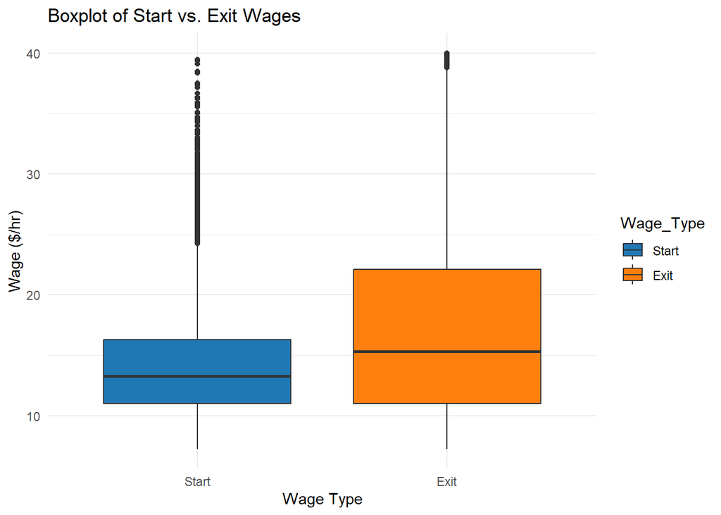

```r
wage_type <- c(rep("Start", sum(!is.na(appr_person_df$st_wage_clean))),
               rep("Exit", sum(!is.na(appr_person_df$end_wage_clean))))

wages <- c(na.omit(appr_person_df$st_wage_clean),
           na.omit(appr_person_df$end_wage_clean))

box_df <- data.frame(Wage_Type = factor(wage_type, levels = c("Start", "Exit")),
                     Wage = wages)

ggplot(box_df, aes(x = Wage_Type, y = Wage, fill = Wage_Type)) +
  geom_boxplot() +
  scale_fill_manual(values = c("Start" = "#1f77b4", "Exit" = "#ff7f0e")) +
  labs(title = "Boxplot of Start vs. Exit Wages",
       x = "Wage Type", y = "Wage ($/hr)") +
  theme_minimal()
```

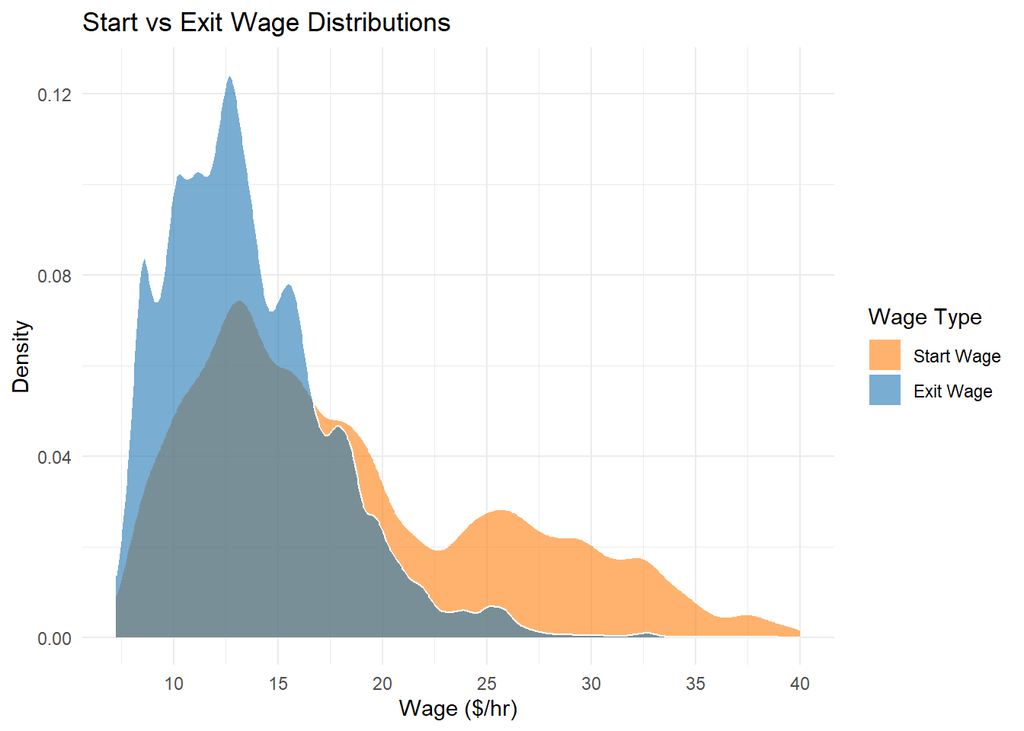

```r
wage_long <- paired_df %>%
  select(st_wage_clean, end_wage_clean) %>%
  tidyr::pivot_longer(cols = everything(), names_to = "wage_type", values_to = "wage")

ggplot(wage_long, aes(x = wage, fill = wage_type)) +
  geom_density(alpha = 0.6, color = "white") +
  scale_fill_manual(values = c("st_wage_clean" = "#1f77b4", "end_wage_clean" = "#ff7f0e"),
                    labels = c("Start Wage", "Exit Wage")) +
  labs(title = "Start vs Exit Wage Distributions",
       x = "Wage ($/hr)",
       y = "Density",
       fill = "Wage Type") +
  theme_minimal() +
  scale_x_continuous(breaks = seq(0, 40, by = 5))
```

**Program Types**

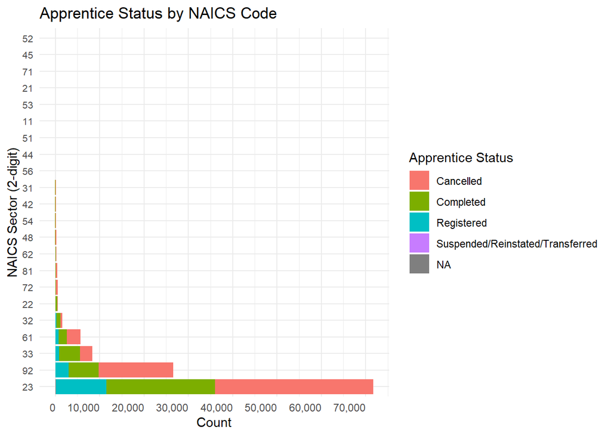

```r
appr_prog_df <- subset(appr_prog_df, !is.na(NAICSCode))

combo_df <- merge(appr_person_df, appr_prog_df, on = 'psId')

combo_df$short_naics <- stringr::str_extract(combo_df$NAICSCode, "^.{2}")

program_df <- combo_df %>%
  left_join(naics_df, by = c("short_naics" = '2022 NAICS US   Code'))

program_df <- program_df %>%
  mutate(`2022 NAICS US Title` = case_when(short_naics %in% 31:33 ~ "Manufacturing",
                                           short_naics %in% 44:45 ~ "Retail Trade",
                                           short_naics %in% 48:49 ~ "Transportation and Warehousing",
                                          TRUE ~ `2022 NAICS US Title`))

ggplot(program_df, aes(x = fct_infreq(as.factor(short_naics)), fill = apprStatus)) +
geom_bar(position = "stack") +
labs(
  title = "Apprentice Status by NAICS Code",
  x = "NAICS Sector (2-digit)",
  y = "Count",
  fill = "Apprentice Status"
) +
coord_flip()+
theme_minimal() +
scale_y_continuous(breaks = seq(0, 300000, by = 10000), labels = scales::comma) +
theme(axis.text.x = element_text(angle = 0, hjust = 1),
  axis.text.y = element_text(size = 8))
```

Overall, most apprentices are geared for select sectors such as Construction (NAICS 23) with over 61% of all apprentices. Public Administration (NAICS 92) follows with nearly 23%, and Manufacturing (NAICS 31–33) with ~8.6%. Sectors like Education, Utilities, and Health Care each have less than 5% of applicants. So the program is really construction, and public administration heavy. Construction is a job role typically associated with male gender roles, so seeing disproportionate apprentices in this industry and the program as a whole showcases that Female labor participation is largely not represented in the apprenticeship program.

```r
program_df %>%
  count(short_naics, `2022 NAICS US Title`) %>%
  mutate(
    Count = scales::comma(n),
    Percent = scales::percent(n / sum(n))
  ) %>%
  arrange(desc(n)) %>%
  select(`2022 NAICS US Title`, short_naics, Count, Percent) %>%
  kable(
    col.names = c('2022 NAICS Title', "NAICS Code (3-digit)", "Count", "Percent"),
    caption = "Distribution of Apprentices by NAICS Code"
  ) %>%
  kable_styling(bootstrap_options = c("striped", "hover", "condensed"))
```

Distribution of Apprentices by NAICS Code

| 2022 NAICS Title | NAICS Code (3-digit) | Count | Percent |
| --- | --- | --- | --- |
| Construction | 23 | 71,697 | 61.50764% |
| Public Administration | 92 | 26,648 | 22.86087% |
| Manufacturing | 33 | 8,329 | 7.14531% |
| Educational Services | 61 | 5,689 | 4.88050% |
| Manufacturing | 32 | 1,573 | 1.34945% |
| Utilities | 22 | 566 | 0.48556% |
| Accommodation and Food Services | 72 | 554 | 0.47527% |
| Other Services (except Public Administration) | 81 | 489 | 0.41950% |
| Health Care and Social Assistance | 62 | 256 | 0.21962% |
| Transportation and Warehousing | 48 | 220 | 0.18873% |
| Professional, Scientific, and Technical Services | 54 | 156 | 0.13383% |
| Wholesale Trade | 42 | 127 | 0.10895% |
| Manufacturing | 31 | 100 | 0.08579% |
| Administrative and Support and Waste Management and Remediation Services | 56 | 43 | 0.03689% |
| Retail Trade | 44 | 35 | 0.03003% |
| Information | 51 | 23 | 0.01973% |
| Agriculture, Forestry, Fishing and Hunting | 11 | 21 | 0.01802% |
| Real Estate and Rental and Leasing | 53 | 20 | 0.01716% |
| Mining, Quarrying, and Oil and Gas Extraction | 21 | 12 | 0.01029% |
| Arts, Entertainment, and Recreation | 71 | 6 | 0.00515% |
| Retail Trade | 45 | 1 | 0.00086% |
| Finance and Insurance | 52 | 1 | 0.00086% |

**Location**

Overall the program favors counties in close proximity to cities. See the table below of the top 10 counties that offer an apprenticeship program. This is not surprising since there are more economic opportunities near cities and higher populations for the labor force. This also suggests that the program is oriented to serving apprentices from metro areas rather than rural areas.

```r
program_df %>%
  count(County, progCity) %>%
  mutate(
    Count = scales::comma(n),
    Percent = scales::percent(n / sum(n))
  ) %>%
  arrange(desc(n)) %>%
  slice_max(n, n = 10) %>%
  select(County, progCity, Count, Percent) %>%
  kable(
    col.names = c("Ohio County", "City/Metro Area", "Count", "Percent"),
    caption = "Distribution of Apprentices by County and Nearest Metro Area"
  ) %>%
  kable_styling(bootstrap_options = c("striped", "hover", "condensed"))
```

Distribution of Apprentices by County and Nearest Metro Area

| Ohio County | City/Metro Area | Count | Percent |
| --- | --- | --- | --- |
| Franklin County | COLUMBUS | 42,577 | 36.52609% |
| Hamilton County | CINCINNATI | 10,759 | 9.22996% |
| Summit County | RICHFIELD | 6,698 | 5.74610% |
| Cuyahoga County | CLEVELAND | 4,974 | 4.26711% |
| Wood County | ROSSFORD | 3,910 | 3.35432% |
| Franklin County | WESTERVILLE | 3,804 | 3.26339% |
| Montgomery County | DAYTON | 3,589 | 3.07894% |
| Butler County | MONROE | 3,103 | 2.66201% |
| Lucas County | TOLEDO | 2,878 | 2.46899% |
| Warren County | SPRINGBORO | 2,251 | 1.93109% |

Next Steps would be to map county level information to assess how individuals in their county of residence, and their county of employment interact and are supported in the program. This geographic information would help identify areas that have strong pipelines of participants in the apprentice program. Other steps include learning more on why applicants leave the apprenticeship program as noted in their free response field. Since this field is free response, I suggest some light natural language processing (NLP) analysis to be performed such as token analysis of keywords. This would also elicit an insider’s view of the program in a structured way. As for the program itself, marketing strategies could be implemented to expand the demographics of participants, and on the employer-side additional variety of job roles would offer more incentives for participants. Employers would likely also need an incentive to offer a program. Also monitoring of the program is recommended as well as developing structured resources for apprentices and employers for mutual success.